# Scaning HTML data using R

Mahbubul Majumder

One of the most abundant sources of the data is HTML pages around the web. Sometimes we would like get those data for analysis. But copying and pasting data from HTML pages ia not a preferable option. We need to figure out how we can obtain the data automatically. This documentation will provide us with detailed instruction on how we can do that using R package XML.

## XML package of R

The R package XML provides wide ranges of functionality to scrap data from the web. We will demonstrate that by scrapping some data from our favourite place www.nfl.com where varieties of data are avaialabe in different pages. First let us include the necessary libraries that will be necessary for this demonstration. We include XML for data scrapping and ggplot2 to plot the data.

```r
# include the library
library(XML)
library(ggplot2)
```

Now we need to specify the exact url of location where the tables of data are avaialbe. For some particular data we go to http://www.nfl.com/ and then click stats. We are interested in all the data of passing yards. Notice that data are extended into three pages. Don’t worry, we carefully examine the link for each pages that you can view on the browser. Notice that only one part of the link is changed when we browse through these data. Lets break the complete link into three parts. Let us save first two parts on variable u1 and u2. We have a total of three pages to scan. Examine the following codes how we constracted three url links namely url1, url2 and url3 for three pages of data.

```r
# specify a url to scan. For this go to http://www.nfl.com/ and then click stats.
#We are interested in all the data of passing yards.

u1 <- "http://www.nfl.com/stats/categorystats?tabSeq=0&season=2012&seasonType=PRE&"
u2 <- "experience=&Submit=Go&archive=true&conference=null&statisticCategory=PASSING&"
url1 <- paste(u1,u2,"d-447263-p=1&qualified=false", sep="")

url2 <- paste(u1,u2,"d-447263-p=2&qualified=false", sep="")
url3 <- paste(u1,u2,"d-447263-p=3&qualified=false", sep="")
```

Each of the above urls contains the link of the page where data tables are available. The function readHTMLTable() reads all the tables in a web link given as an argument. The command readHTMLTable(url1) will read all the tables on url1. On any url there could be more than one table. We need to know which table contains our desired data. We can check that by inspecting the HTML source codes. Fo this particular example we notice that the desired data is in tablle name result. The following codes shows how we obtain the result tables from each of the three urls.

```r
# Scan the table
tables1 <- readHTMLTable(url1)
tables2 <- readHTMLTable(url2)
tables3 <- readHTMLTable(url3)

# In HTML codes id="result" contains the desired data
bd1 <- tables1$result
bd2 <- tables2$result
bd3 <- tables3$result
```

The tables bd1, bd2 and bd3 contains the data tables avaialbe on te web pages. We would like to merge them into one table say datPassingYard. Since columns of all the tables are same, we can do the operation.

```r
datPassingYard <- rbind(bd1,bd2,bd3)
```

Now let us plot some of the data we just obtained. But before doing that we need to examine the data and table columns. We need to clean the data before we can do anything with the data. First notice that the column names contain some unwanted characters.

```r
names(datPassingYard)
```

```
##  [1] "Rk"      "Player"  "Team"    "Pos"     "\nComp"  "\nAtt"   "\nPct"
##  [8] "\nAtt/G" "\nYds"   "\nAvg"   "\nYds/G" "\nTD"    "\nInt"   "\n1st"
## [15] "\n1st%"  "\nLng"   "\n20+"   "\n40+"   "\nSck"   "\nRate"
```

We don’t wnat to keep those new line characters (n) in the begining of the column names. Instead, we would substitute `n’ with nothing (“”). For this we use the powerful function gsub(). These are the kind of issues we have to deal with when we read data from internet.

```r
names(datPassingYard) <- gsub("\n","",names(datPassingYard))
```

Now we want to plot the average passing distences by player. For this we would like review the summary of average passing distences. Notice that the Avg column is not a numeric field but a factor. You can check if it is a factor by using function is.factor(). We have to convert the factor variable to a numerical variable. Notice how we did this by converting factor to character then to numeric.

```r
is.factor(datPassingYard$Avg)
```

```
## [1] TRUE
```

```r
datPassingYard$Avg = as.numeric(as.character(datPassingYard$Avg))
```

Since there are many players we would plot only first 20 players whose average passing distences are most. Notice how we deal with ordering the players in the plot. We wanted to print player with highest avarage passing distence to be on top.

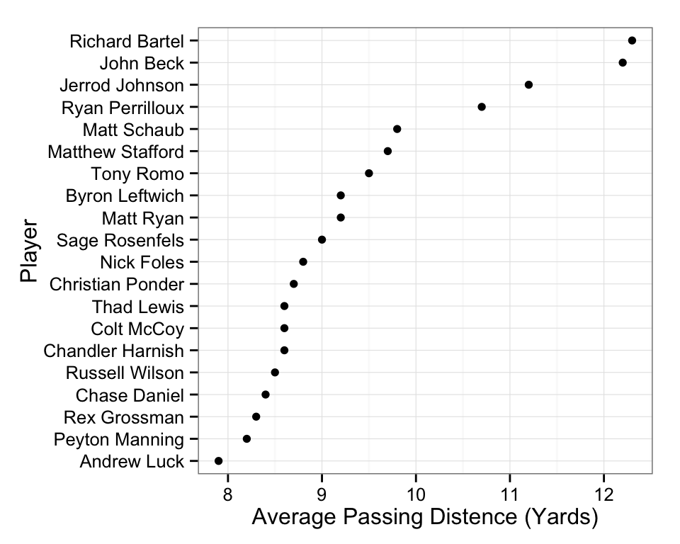

## More example

We often visit wikipedia for information. It is a nice source of useful data. This example will demonstrate how we can obtain data from a wikipedia page.

Suppose we are particularly interested in the languges that are spoken by most of the people. Which languages are mostly spoken in the world. Does english rank first? Which language do you think rank second?

To answer these question we can go to the following wikipedia page

http://en.wikipedia.org/wiki/List_of_languages_by_number_of_native_speakers

Let us try to read that page and extract the information from that page

```r
library(XML)
url <- "http://en.wikipedia.org/wiki/List_of_languages_by_number_of_native_speakers"
tables <- readHTMLTable(url)
```

Now notice that the table in this link does not have any ID to specifically get the data from. But if you examine the source of the page, the first table is the data table. Thus we pick first table in the list of tables as our data. To obtain this notice we use [[1]] to pick the first element from the list which should be the data table. Also we are only interested of the name of language and how many people speaks that language. Notice how we picked only column 2 and 3 from the raw data we obtained and put this subset of the data into a new data frame dat.

```r
# getting the first element of the list
datraw <- tables[[1]]

#For plotting purpose we only need column 2 and 3.
dat <- datraw[,2:3]
names(dat) <- c("language","native_speaker")
head(dat)
```

```
##              language native_speaker
## 1 Mandarin\n官話/官话           955*
## 2      SpanishEspañol           405*
## 3             English           360*
## 4         Hindi\nहिन्दी           310*
## 5     Arabic\nالعربية           295*
## 6 PortuguesePortuguês           215*
```

Notice that the data is not clean. We have a ‘*’ in the number of native speaker. Also for Arabic, the number just messedup. We have to carefully review the data before we can use it. But first let us remove the ‘*’ from column 2 and make the column numeric. Also notice in the first column we have some non-english character that we don’t want to print. Afterall how many of us know all those non-english charatcer.

```r
dat$speaker <- as.numeric(gsub("\\*","",as.character(dat$native_speaker)))

# cleaning non-english character
dat$lang <- substr(with(dat,gsub("\\W","",language)),1,20)

# One of the language name is too big, we truncate upto 20 charater
dat$lan <- with(dat, substr(lang,1,20))
```

Now let us plot the data to show languagewise ranks and their relative position. Notice how we ordered the language names to plot them.

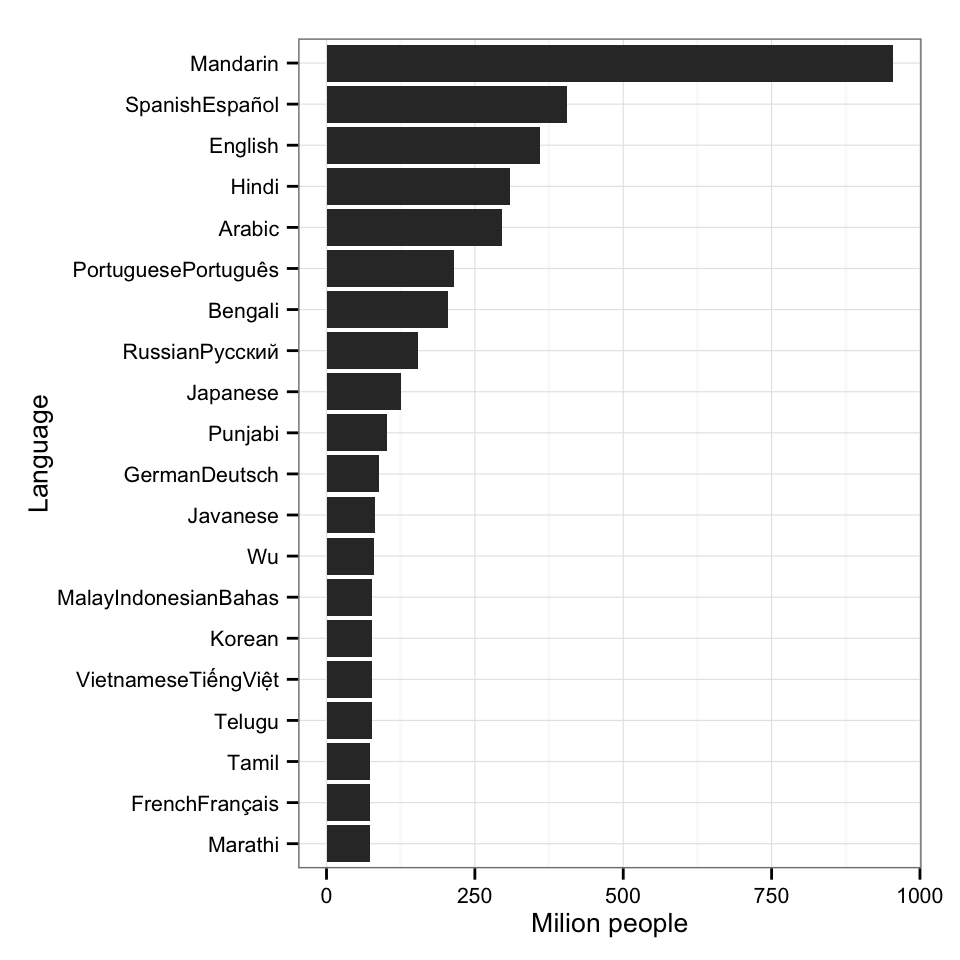

```r
ggplot(dat[order(dat$speaker, decreasing = T)[1:20],]) +
  geom_bar(aes(factor(lan,levels= lan[order(speaker)]),speaker), stat="identity") +
  coord_flip() + theme_bw(10)+
  ylab("Milion people") +xlab("Language")
```